# MOBEAST fDOM Preliminary Results

Keanu Rochette

2025-02-05

## Load Libraries

```r
library(tidyverse)
library(here)
library(janitor)
library(ggrepel)
library(ghibli)
library(gt)
library(patchwork)
library(RColorBrewer)

library(car) # ANOVA package
library(ggeffects)
library(effects) #dependency for ggeffects
library(ggResidpanel) #residual panel
library(GGally)
library(emmeans)
```

## Load function

```r
source(here("functions", "function_ANOVA_nunu.R"))
```

```r
heatmap <- function(data , x, y, color) {
  #creating a function using the penguin dataset,
  # x and y variables to plot and a color component
  # geom_func allows to swap the style of the plot


  ggplot(data , aes(x= {{x}}, y= {{y}}, fill = {{color}})) +
    geom_tile()+
    theme_bw() +
    theme(plot.title = element_text(size=14, face = "bold"),
        plot.subtitle = element_text(size=12),
        axis.title = element_text(size = 12, face = "bold"),
        axis.text = element_text(size = 12),
        strip.text.x = element_text(size = 12, face = "bold"),
        legend.title=element_text(size=12, face = "bold"),
        legend.text=element_text(size=12),
        axis.text.x = element_text(angle= 45, hjust= 1),
        panel.background = element_rect(fill = "azure1"))
}
```

## Load Data

```r
fDOM <- read_csv(here("data", "fDOM", "fDOM_sorted.csv"))
```

## Data visualization theme

```r
nunu_theme <- theme_bw() +
  theme(plot.title = element_text(size=14, face = "bold"),
        plot.subtitle = element_text(size=12),
        axis.title = element_text(size = 12, face = "bold"),
        axis.text = element_text(size = 12),
        strip.text.x = element_text(size = 12, face = "bold"),
        legend.title=element_text(size=12, face = "bold"),
        legend.text=element_text(size=12),
        axis.text.x = element_text(angle= 45, hjust= 1),
        panel.background = element_rect(fill = "azure1"))
```

## Hierarchical hypothesis testing

### Design function to automate the process

```r
fDOM_hyp_test <- function(data, fDOM_var) {

  # look at the baseline of endmembers: lagoon, bay and ocean channel and rain
  ## table summary of average and stand dev with endmembers
  ## the goal is to see is the endmember values are consistent

  endmem_summary <<- data %>% group_by(sample_type) %>%
  summarise(avg= mean({{fDOM_var}}, rm.na = T),
            std_dev = sd({{fDOM_var}}))

  ## plot the endmember values on a heat map for visualization
  heat_map <<- ggplot(data , aes(x= sample_type, y = factor(date_time),
                    fill = {{fDOM_var}})) +
    geom_tile()+
    scale_fill_distiller(palette = "RdYlBu")+
    nunu_theme


  # Is the inflow consistent ?
  ## Remove the end members of the data set
  fDOM_inflow <<- data %>% select(tank_number, treatment, sample_type, date,
                                    time, date_time, {{fDOM_var}}) %>%
    filter (treatment != "Endmember", treatment!= "Rain")

  ## Boxplot to show the distribution of variables without endmembers
  boxgraph <<- fDOM_inflow %>% ggplot(aes(x= treatment, y= {{fDOM_var}}))+
      geom_boxplot(aes(fill = treatment))+
      nunu_theme

    ## calculate mean and std dev without the endmembers
    inflow_summary <<- fDOM_inflow%>%
      group_by(treatment) %>%
      summarise(avg = mean({{fDOM_var}}, na.rm = T),
            std_dev = sd({{fDOM_var}}, na.rm = T))

  ## graph distribution of the std dev
  point_graph <<- fDOM_inflow%>%
    group_by(treatment) %>%
    summarise(avg = mean({{fDOM_var}}, na.rm = T),
            std_dev = sd({{fDOM_var}}, na.rm = T)) %>%
    ggplot(aes(x= treatment, y= std_dev))+
    geom_point(aes(color = treatment, size = 3))+
    scale_y_continuous(limits = c(0, NA))+
    nunu_theme

  # remove the inflow data point
  fDOM_ctrl_trmt <- fDOM_inflow %>%
    filter (treatment != "Inflow") %>%
    mutate(treatment = factor(treatment,
                            levels= c("Control", "Coral", "Rubble", "Algae")))
  fDOM_ctrl_trmt <<- fDOM_ctrl_trmt
      # treatment must be ordered factors for future linear model

  print("Outputs: endmem_summary, heat_map, boxgraph, fDOM_inflow, inflow_summary,
        point_graph, fDOM_ctrl_trmt")
}
```

### CobleA

```r
fDOM_hyp_test(data = fDOM, fDOM_var = coble_a)
```

```
## [1] "Outputs: endmem_summary, heat_map, boxgraph, fDOM_inflow, inflow_summary,\n        point_graph, fDOM_ctrl_trmt"
```

#### Baseline assessment

Endmembers, i.e. Lagoon, Ocean channel, Bay and Rain, were measured to assess the “baseline” values of the environmental parameters measured, here cobleA which is a time of fDOM.

We calculated the the average and standard deviation.

```r
fDOM %>% group_by(sample_type) %>%
  summarise(avg= mean(coble_a, rm.na = T),
            std_dev = sd(coble_a))
```

```
## # A tibble: 9 × 3
##   sample_type     avg   std_dev
##   <chr>         <dbl>     <dbl>
## 1 Algae       0.0103   0.00428
## 2 Bay         0.00528  0.00139
## 3 Control     0.00914  0.00385
## 4 Coral       0.00852  0.00331
## 5 Inflow      0.00916  0.00255
## 6 Lagoon      0.00383  0.000144
## 7 Ocean       0.00524  0.00253
## 8 Rain        0.0218  NA
## 9 Rubble      0.00969  0.00324
```

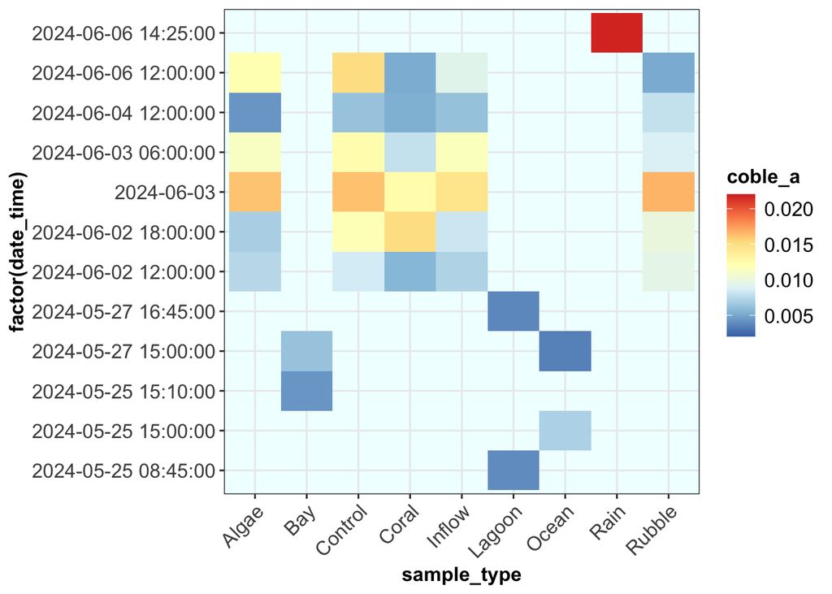

```r
heatmap(data = fDOM, x= sample_type, y = factor(date_time), color = coble_a) +
  scale_fill_distiller(palette = "RdYlBu")
```

#### Variations in inflow

The inflow was measured as a baseline for water that entered the tank.

It looks like the variation in flow are minimal and are there consistent.  
The box plot plot shows minimal spread of the data. Plotting the standard deviations shows a low standard deviation.

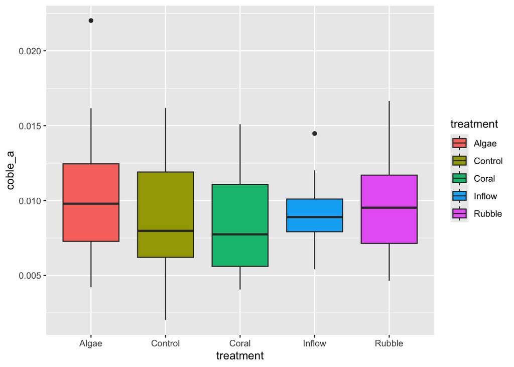

```r
fDOM %>% select(tank_number, treatment, sample_type, date, time, date_time, coble_a) %>% filter (treatment != "Endmember", treatment!= "Rain") %>%
  group_by(treatment) %>%
  ggplot(aes(x= treatment, y= coble_a))+
  geom_boxplot(aes(fill = treatment))
```

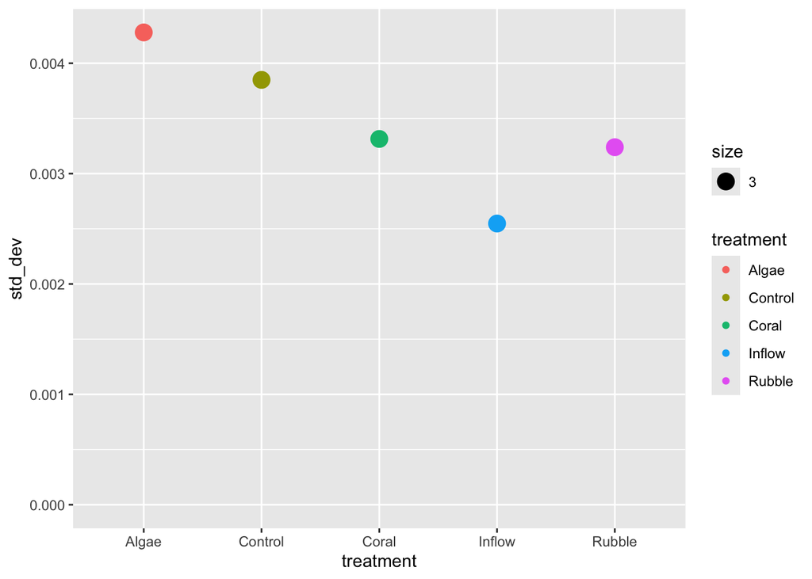

```r
fDOM %>% select(tank_number, treatment, sample_type, date, time, date_time, coble_a) %>% filter (treatment != "Endmember", treatment!= "Rain") %>%
  group_by(treatment) %>%
  summarise(avg = mean(coble_a, na.rm = T),
            std_dev = sd(coble_a, na.rm = T)) %>%
  ggplot(aes(x= treatment, y= std_dev))+
  geom_point(aes(color = treatment, size = 3))+
  scale_y_continuous(limits = c(0, NA))
```

#### Comparing the treatments to the control tanks

We saw that the inflow was fairly consistent, we can now test the treatments vs. control. We are applying a Dunnett test to calculate the contrast between treatments and control.

```r
cobA <- fDOM %>% select(tank_number, treatment, sample_type, date, time, date_time, coble_a) %>% filter (treatment != "Endmember", treatment!= "Rain", treatment != "Inflow") %>%
  mutate(treatment = factor(treatment, levels= c("Control", "Coral", "Rubble", "Algae")))
```

Setting up the linear model to apply the Dunnett test via the emmeans() function. p-values of the contrast show not significant differences between the control and the treatments.

```r
cobA_lm <-  lm(coble_a ~ treatment, data = cobA)

emmeans(cobA_lm, specs=(trt.vs.ctrl ~ treatment))
```

```
## $emmeans
##  treatment  emmean       SE df lower.CL upper.CL
##  Control   0.00914 0.000754 92  0.00764   0.0106
##  Coral     0.00852 0.000754 92  0.00702   0.0100
##  Rubble    0.00969 0.000754 92  0.00819   0.0112
##  Algae     0.01033 0.000754 92  0.00883   0.0118
##
## Confidence level used: 0.95
##
## $contrasts
##  contrast          estimate      SE df t.ratio p.value
##  Coral - Control  -0.000619 0.00107 92  -0.580  0.8595
##  Rubble - Control  0.000549 0.00107 92   0.515  0.8895
##  Algae - Control   0.001191 0.00107 92   1.116  0.5399
##
## P value adjustment: dunnettx method for 3 tests
```

### Conclusion cobleA

There is no difference between control and treatments

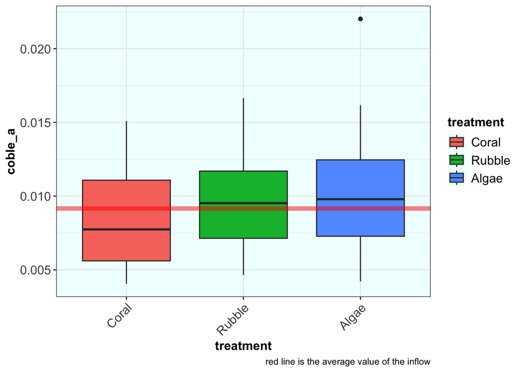

```r
cobA %>% filter(treatment != "Control") %>%
   ggplot(aes(x= treatment, y= coble_a))+
  geom_boxplot(aes(fill = treatment)) +
  geom_hline(yintercept = 0.009160615, color = "red", linewidth = 2, alpha = 0.5)+
  labs(caption = "red line is the average value of the inflow")+
  nunu_theme
```

### CobleM

```r
fDOM_hyp_test(data = fDOM, fDOM_var = coble_m)
```

```
## [1] "Outputs: endmem_summary, heat_map, boxgraph, fDOM_inflow, inflow_summary,\n        point_graph, fDOM_ctrl_trmt"
```

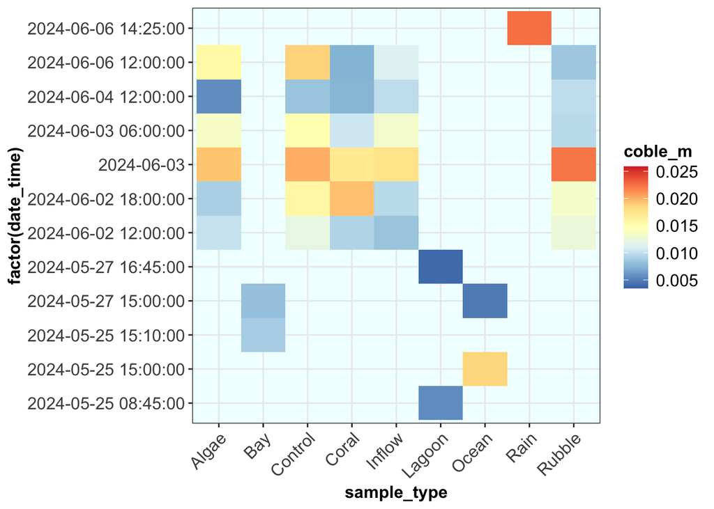

```r
heat_map
```

```r
endmem_summary
```

```
## # A tibble: 9 × 3
##   sample_type     avg   std_dev
##   <chr>         <dbl>     <dbl>
## 1 Algae       0.0127   0.00508
## 2 Bay         0.00851  0.000461
## 3 Control     0.0117   0.00455
## 4 Coral       0.0112   0.00426
## 5 Inflow      0.0111   0.00295
## 6 Lagoon      0.00476  0.00115
## 7 Ocean       0.0117   0.00977
## 8 Rain        0.0225  NA
## 9 Rubble      0.0120   0.00380
```

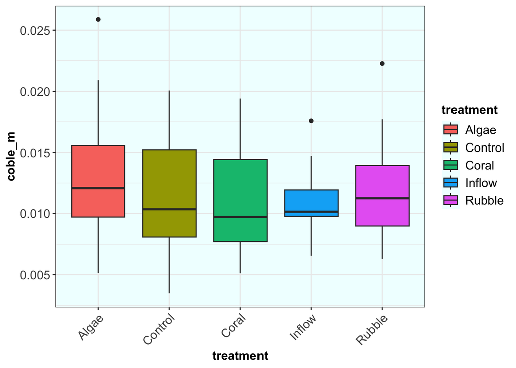

```r
boxgraph
```

```r
inflow_summary
```

```
## # A tibble: 5 × 3
##   treatment    avg std_dev
##   <chr>      <dbl>   <dbl>
## 1 Algae     0.0127 0.00508
## 2 Control   0.0117 0.00455
## 3 Coral     0.0112 0.00426
## 4 Inflow    0.0111 0.00295
## 5 Rubble    0.0120 0.00380
```

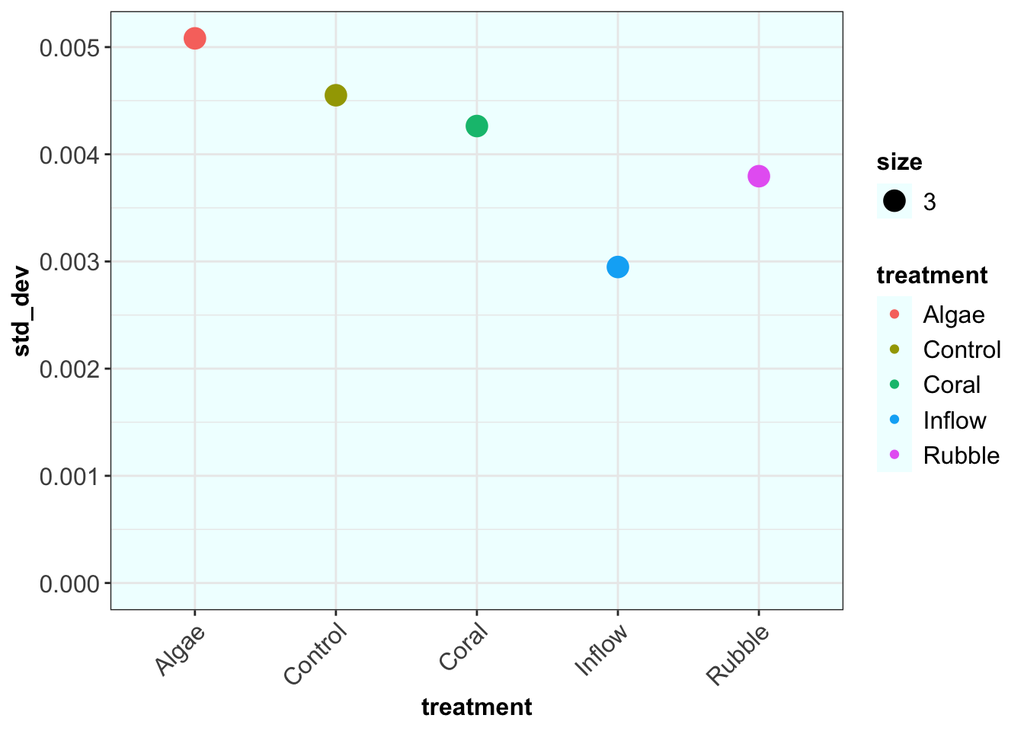

```r
point_graph
```

```r
# run contrast between control and treatment
  ##  set up linear model to analyze contrasts
fDOM_lm <- lm(coble_m ~ treatment, data = fDOM_ctrl_trmt)


  ## run emmeans to see the difference btwn control and treatment
emmeans(fDOM_lm, specs=(trt.vs.ctrl ~ treatment))
```

```
## $emmeans
##  treatment emmean       SE df lower.CL upper.CL
##  Control   0.0117 0.000908 92  0.00990   0.0135
##  Coral     0.0112 0.000908 92  0.00945   0.0131
##  Rubble    0.0120 0.000908 92  0.01023   0.0138
##  Algae     0.0127 0.000908 92  0.01094   0.0145
##
## Confidence level used: 0.95
##
## $contrasts
##  contrast          estimate      SE df t.ratio p.value
##  Coral - Control  -0.000454 0.00128 92  -0.354  0.9486
##  Rubble - Control  0.000332 0.00128 92   0.259  0.9730
##  Algae - Control   0.001040 0.00128 92   0.810  0.7334
##
## P value adjustment: dunnettx method for 3 tests
```

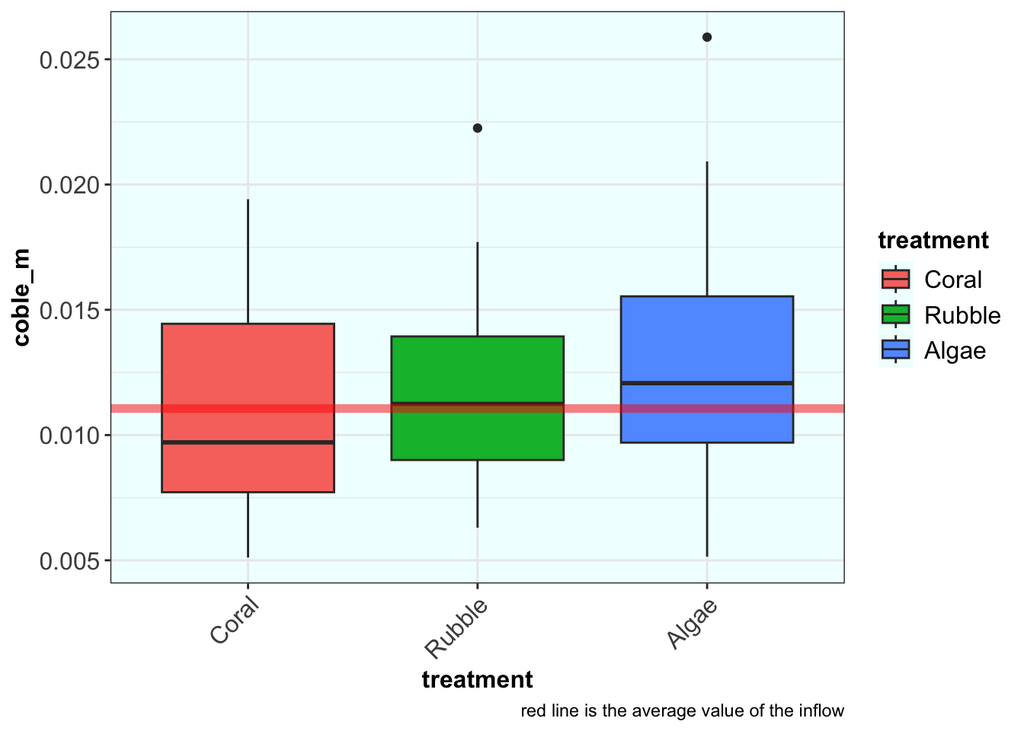

```r
fDOM_ctrl_trmt %>% filter(treatment != "Control") %>%
   ggplot(aes(x= treatment, y= coble_m))+
  geom_boxplot(aes(fill = treatment)) +
  geom_hline(yintercept = 0.01105936, color = "red", linewidth = 2, alpha = 0.5)+
  labs(caption = "red line is the average value of the inflow")+
  nunu_theme
```

### CobleB

```r
fDOM_hyp_test(data = fDOM, fDOM_var = coble_b)
```

```
## [1] "Outputs: endmem_summary, heat_map, boxgraph, fDOM_inflow, inflow_summary,\n        point_graph, fDOM_ctrl_trmt"
```

```r
endmem_summary
```

```
## # A tibble: 9 × 3
##   sample_type    avg  std_dev
##   <chr>        <dbl>    <dbl>
## 1 Algae       0.0709  0.0262
## 2 Bay         0.0569  0.0180
## 3 Control     0.0736  0.0353
## 4 Coral       0.0793  0.0323
## 5 Inflow      0.0541  0.0157
## 6 Lagoon      0.0530  0.0196
## 7 Ocean       0.0584  0.00266
## 8 Rain        0.0503 NA
## 9 Rubble      0.0757  0.0316
```

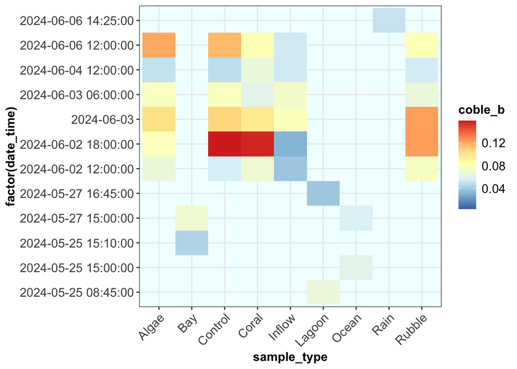

```r
heat_map
```

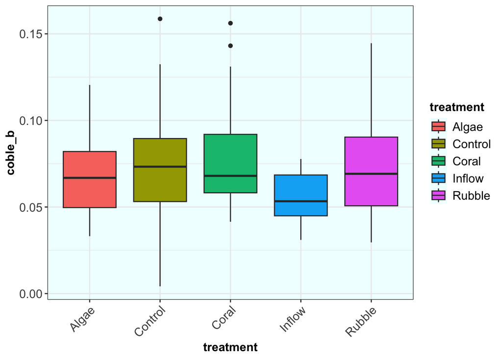

```r
boxgraph
```

```r
inflow_summary
```

```
## # A tibble: 5 × 3
##   treatment    avg std_dev
##   <chr>      <dbl>   <dbl>
## 1 Algae     0.0709  0.0262
## 2 Control   0.0736  0.0353
## 3 Coral     0.0793  0.0323
## 4 Inflow    0.0541  0.0157
## 5 Rubble    0.0757  0.0316
```

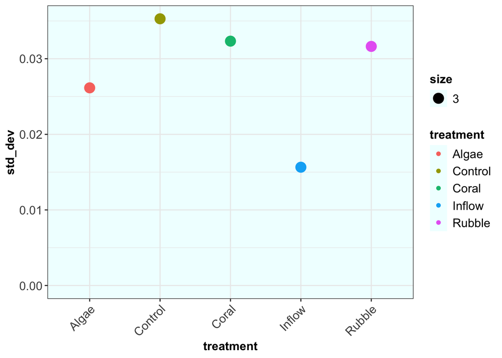

```r
point_graph
```

```r
# run contrast between control and treatment
  ##  set up linear model to analyze contrasts
fDOM_lm <- lm(coble_b ~ treatment, data = fDOM_ctrl_trmt)


  ## run emmeans to see the difference btwn control and treatment
emmeans(fDOM_lm, specs=(trt.vs.ctrl ~ treatment))
```

```
## $emmeans
##  treatment emmean      SE df lower.CL upper.CL
##  Control   0.0736 0.00643 92   0.0608   0.0864
##  Coral     0.0793 0.00643 92   0.0666   0.0921
##  Rubble    0.0757 0.00643 92   0.0629   0.0885
##  Algae     0.0709 0.00643 92   0.0581   0.0837
##
## Confidence level used: 0.95
##
## $contrasts
##  contrast         estimate     SE df t.ratio p.value
##  Coral - Control   0.00574 0.0091 92   0.631  0.8342
##  Rubble - Control  0.00213 0.0091 92   0.234  0.9782
##  Algae - Control  -0.00271 0.0091 92  -0.298  0.9640
##
## P value adjustment: dunnettx method for 3 tests
```

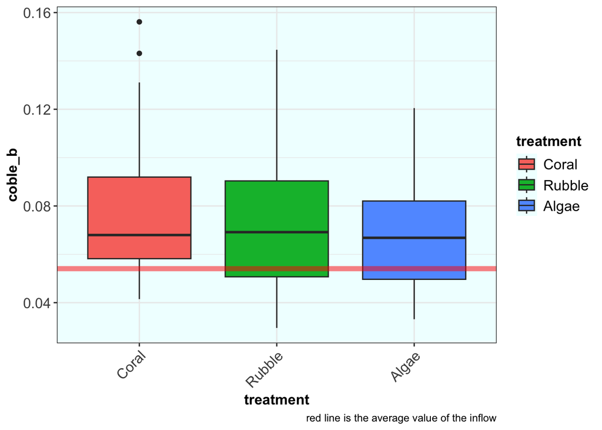

```r
fDOM_ctrl_trmt %>% filter(treatment != "Control") %>%
   ggplot(aes(x= treatment, y= coble_b))+
  geom_boxplot(aes(fill = treatment)) +
  geom_hline(yintercept = 0.05406242, color = "red", linewidth = 2, alpha = 0.5)+
  labs(caption = "red line is the average value of the inflow")+
  nunu_theme
```

### CobleC

```r
fDOM_hyp_test(data = fDOM, fDOM_var = coble_c)
```

```
## [1] "Outputs: endmem_summary, heat_map, boxgraph, fDOM_inflow, inflow_summary,\n        point_graph, fDOM_ctrl_trmt"
```

```r
endmem_summary
```

```
## # A tibble: 9 × 3
##   sample_type     avg    std_dev
##   <chr>         <dbl>      <dbl>
## 1 Algae       0.00965  0.00461
## 2 Bay         0.00443  0.00131
## 3 Control     0.00662  0.00321
## 4 Coral       0.00714  0.00330
## 5 Inflow      0.00566  0.00191
## 6 Lagoon      0.00408  0.000330
## 7 Ocean       0.00326  0.0000622
## 8 Rain        0.0196  NA
## 9 Rubble      0.00833  0.00314
```

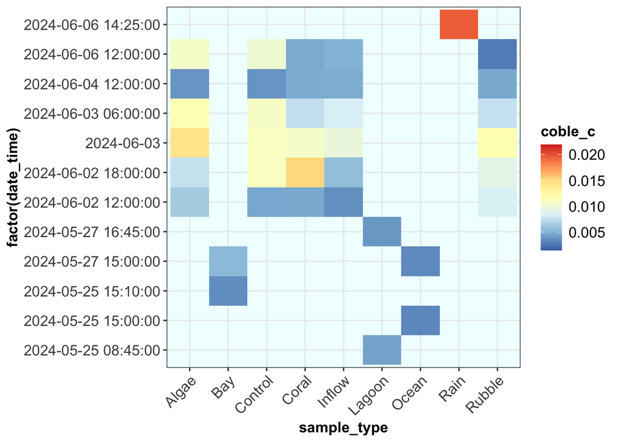

```r
heat_map
```

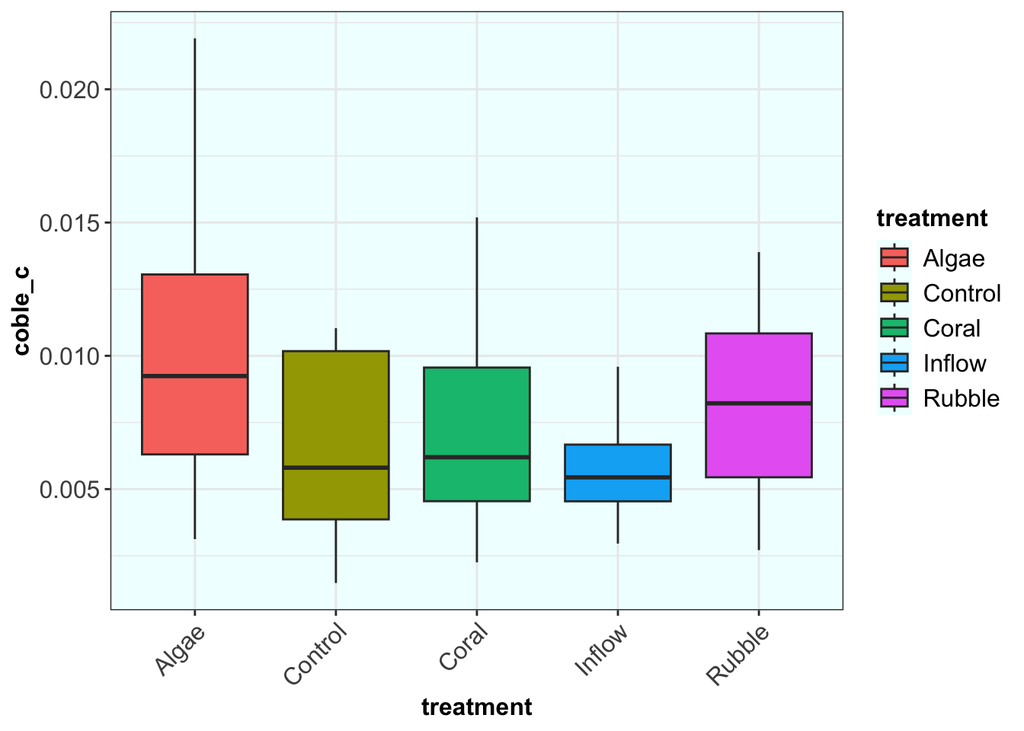

```r
boxgraph
```

```r
inflow_summary
```

```
## # A tibble: 5 × 3
##   treatment     avg std_dev
##   <chr>       <dbl>   <dbl>
## 1 Algae     0.00965 0.00461
## 2 Control   0.00662 0.00321
## 3 Coral     0.00714 0.00330
## 4 Inflow    0.00566 0.00191
## 5 Rubble    0.00833 0.00314
```

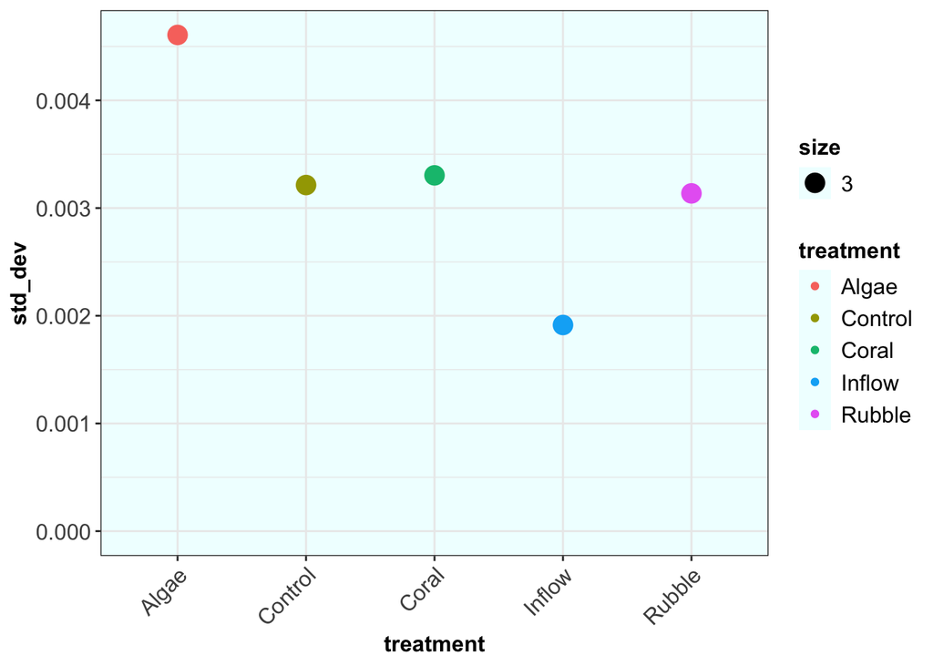

```r
point_graph
```

```r
# run contrast between control and treatment
  ##  set up linear model to analyze contrasts
fDOM_lm <- lm(coble_c~ treatment, data = fDOM_ctrl_trmt)


  ## run emmeans to see the difference btwn control and treatment
emmeans(fDOM_lm, specs=(trt.vs.ctrl ~ treatment))
```

```
## $emmeans
##  treatment  emmean       SE df lower.CL upper.CL
##  Control   0.00662 0.000738 92  0.00515  0.00808
##  Coral     0.00714 0.000738 92  0.00567  0.00860
##  Rubble    0.00833 0.000738 92  0.00686  0.00979
##  Algae     0.00965 0.000738 92  0.00819  0.01112
##
## Confidence level used: 0.95
##
## $contrasts
##  contrast         estimate      SE df t.ratio p.value
##  Coral - Control  0.000519 0.00104 92   0.497  0.8971
##  Rubble - Control 0.001709 0.00104 92   1.637  0.2514
##  Algae - Control  0.003033 0.00104 92   2.905  0.0130
##
## P value adjustment: dunnettx method for 3 tests
```

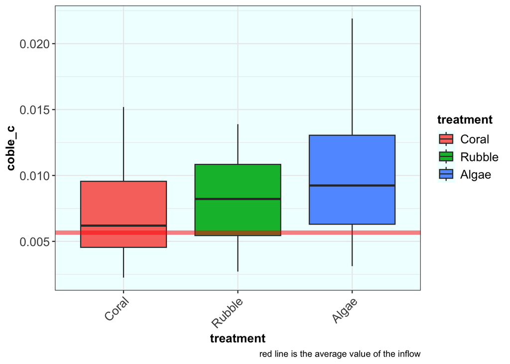

```r
fDOM_ctrl_trmt %>% filter(treatment != "Control") %>%
   ggplot(aes(x= treatment, y= coble_c))+
  geom_boxplot(aes(fill = treatment)) +
  geom_hline(yintercept = 0.005663924   , color = "red", linewidth = 2, alpha = 0.5)+
  labs(caption = "red line is the average value of the inflow")+
  nunu_theme
```

### CobleT

```r
fDOM_hyp_test(data = fDOM, fDOM_var = coble_t)
```

```
## [1] "Outputs: endmem_summary, heat_map, boxgraph, fDOM_inflow, inflow_summary,\n        point_graph, fDOM_ctrl_trmt"
```

```r
endmem_summary
```

```
## # A tibble: 9 × 3
##   sample_type    avg   std_dev
##   <chr>        <dbl>     <dbl>
## 1 Algae       0.0685  0.0333
## 2 Bay         0.212   0.171
## 3 Control     0.0793  0.0552
## 4 Coral       0.0831  0.0529
## 5 Inflow      0.0712  0.0598
## 6 Lagoon      0.0172  0.000940
## 7 Ocean       0.146   0.116
## 8 Rain        0.0267 NA
## 9 Rubble      0.0721  0.0428
```

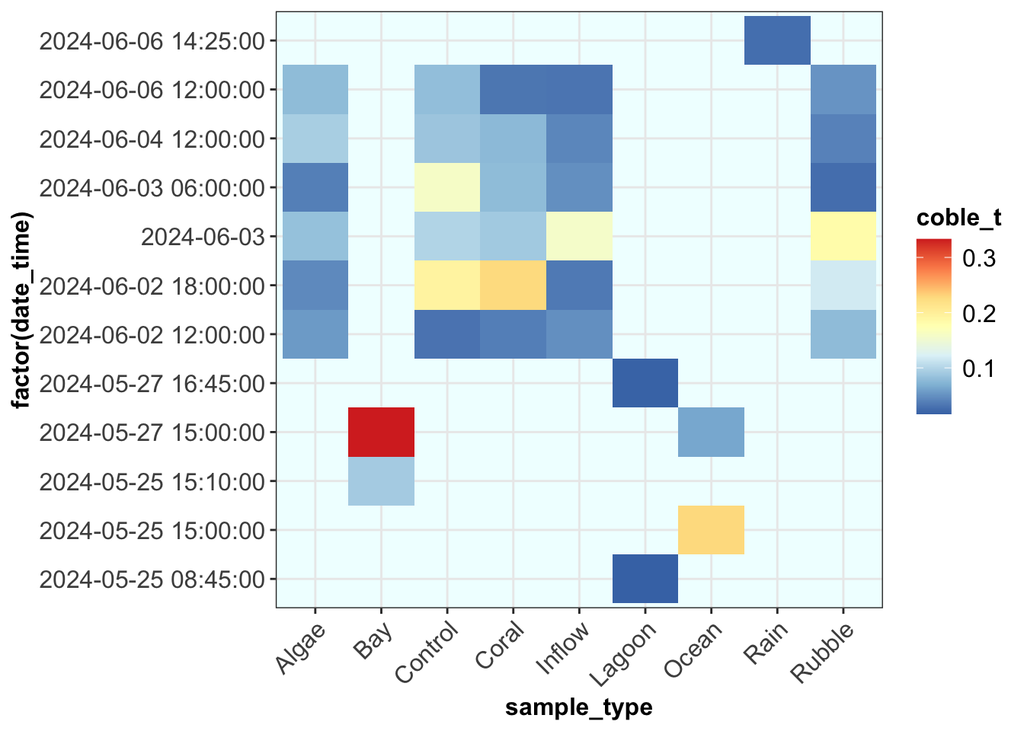

```r
heat_map
```

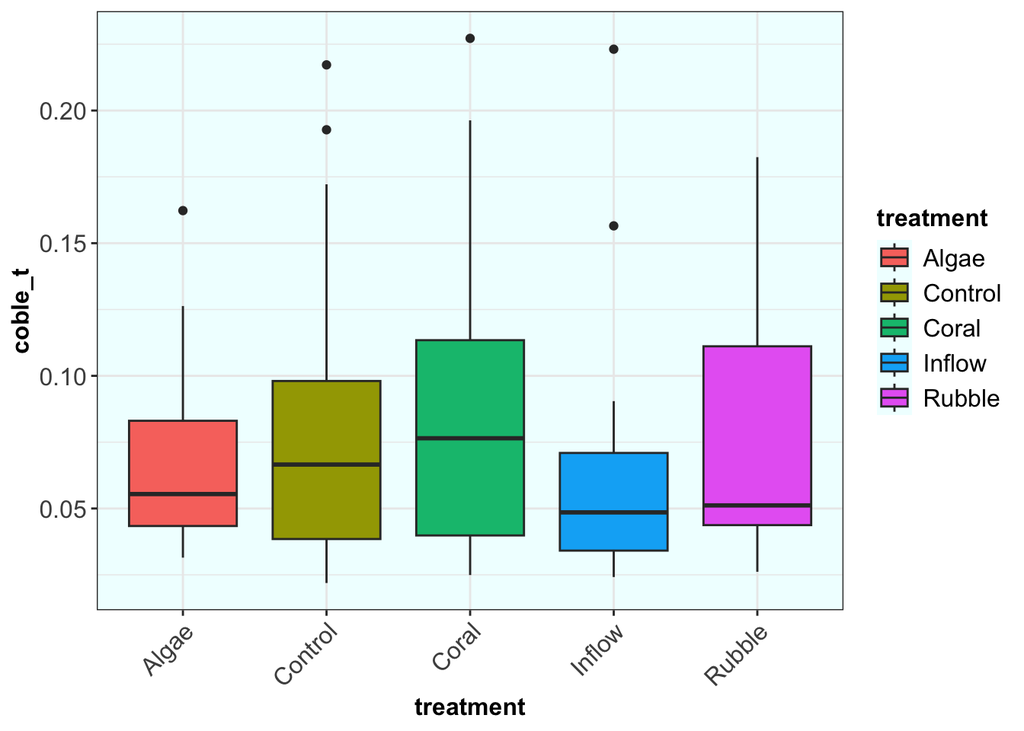

```r
boxgraph
```

```r
inflow_summary
```

```
## # A tibble: 5 × 3
##   treatment    avg std_dev
##   <chr>      <dbl>   <dbl>
## 1 Algae     0.0685  0.0333
## 2 Control   0.0793  0.0552
## 3 Coral     0.0831  0.0529
## 4 Inflow    0.0712  0.0598
## 5 Rubble    0.0721  0.0428
```

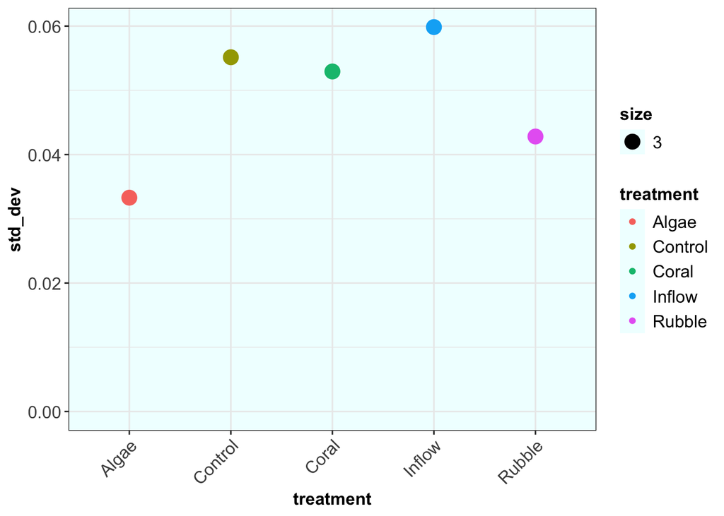

```r
point_graph
```

```r
# run contrast between control and treatment
  ##  set up linear model to analyze contrasts
fDOM_lm <- lm(coble_t ~ treatment, data = fDOM_ctrl_trmt)


  ## run emmeans to see the difference btwn control and treatment
emmeans(fDOM_lm, specs=(trt.vs.ctrl ~ treatment))
```

```
## $emmeans
##  treatment emmean      SE df lower.CL upper.CL
##  Control   0.0793 0.00957 92   0.0603   0.0983
##  Coral     0.0831 0.00957 92   0.0641   0.1021
##  Rubble    0.0721 0.00957 92   0.0531   0.0911
##  Algae     0.0685 0.00957 92   0.0495   0.0875
##
## Confidence level used: 0.95
##
## $contrasts
##  contrast         estimate     SE df t.ratio p.value
##  Coral - Control   0.00387 0.0135 92   0.286  0.9668
##  Rubble - Control -0.00720 0.0135 92  -0.532  0.8817
##  Algae - Control  -0.01073 0.0135 92  -0.793  0.7436
##
## P value adjustment: dunnettx method for 3 tests
```

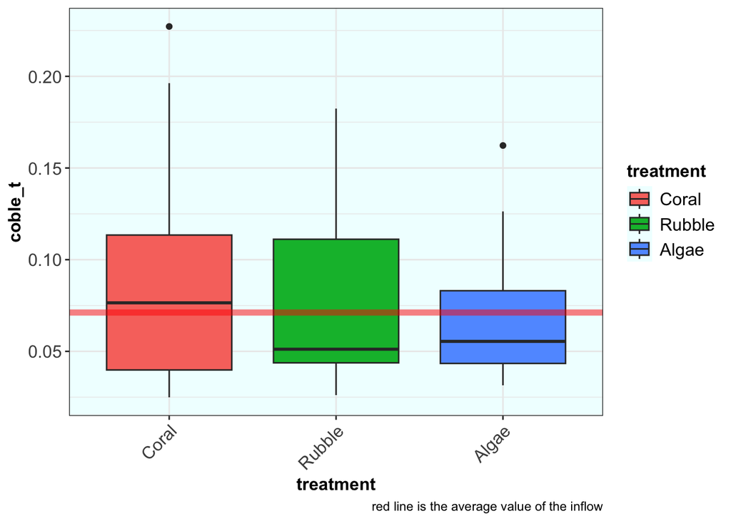

```r
fDOM_ctrl_trmt %>% filter(treatment != "Control") %>%
   ggplot(aes(x= treatment, y= coble_t))+
  geom_boxplot(aes(fill = treatment)) +
  geom_hline(yintercept = 0.07117004, color = "red", linewidth = 2, alpha = 0.5)+
  labs(caption = "red line is the average value of the inflow")+
  nunu_theme
```

### M to C Ratio

```r
fDOM_hyp_test(data = fDOM, fDOM_var = m_to_c)
```

```
## [1] "Outputs: endmem_summary, heat_map, boxgraph, fDOM_inflow, inflow_summary,\n        point_graph, fDOM_ctrl_trmt"
```

```r
endmem_summary
```

```
## # A tibble: 9 × 3
##   sample_type   avg std_dev
##   <chr>       <dbl>   <dbl>
## 1 Algae       0.737  0.134
## 2 Bay         0.525  0.183
## 3 Control     0.548  0.123
## 4 Coral       0.623  0.124
## 5 Inflow      0.506  0.0731
## 6 Lagoon      0.874  0.141
## 7 Ocean       0.434  0.369
## 8 Rain        0.869 NA
## 9 Rubble      0.686  0.139
```

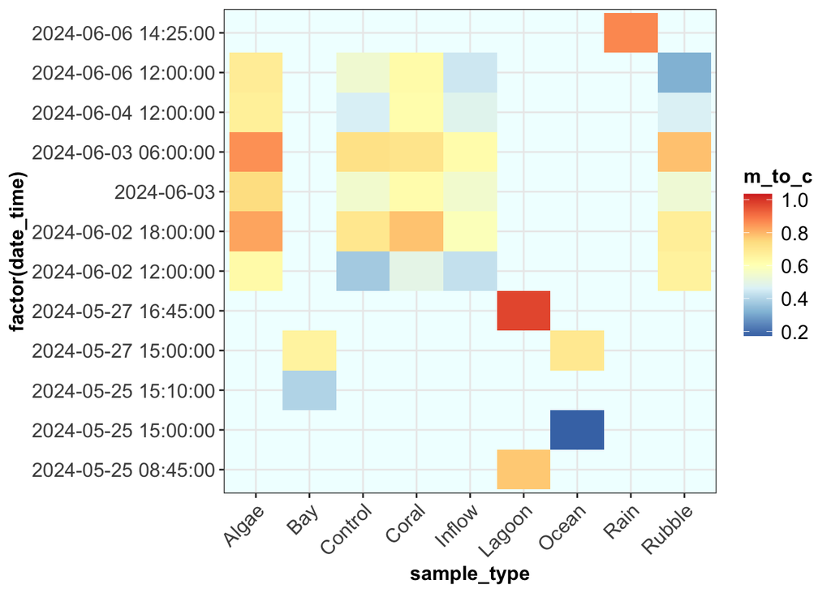

```r
heat_map
```

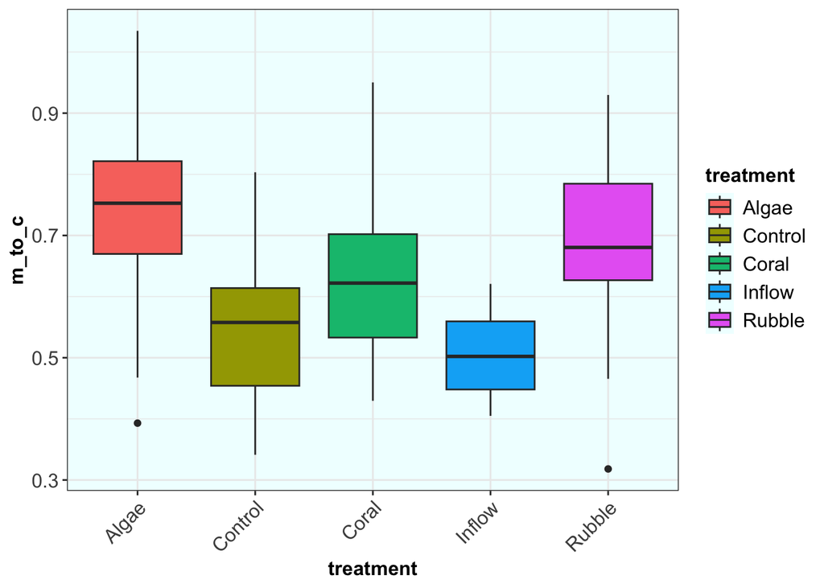

```r
boxgraph
```

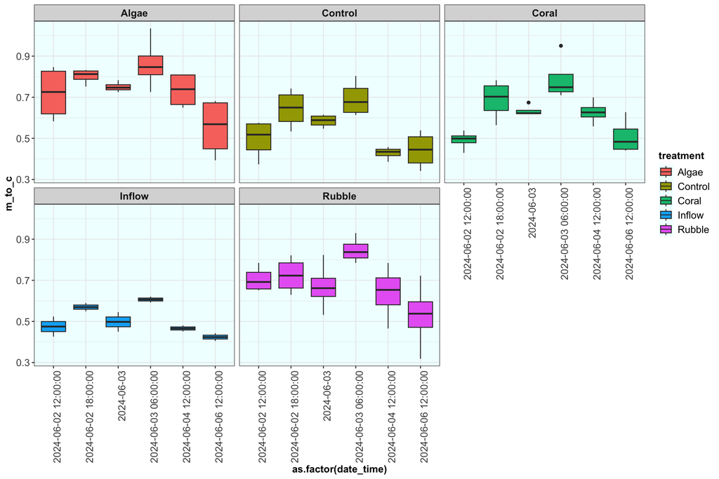

```r
fDOM_inflow %>%
  ggplot(aes(x= as.factor(date_time), y = m_to_c,
             group= date_time, fill = treatment)) +
  geom_boxplot()+
  facet_wrap(.~ treatment )+
  nunu_theme +
  theme(axis.text.x = element_text(angle= 90, hjust= 1))
```

```r
# Are the fDOM concentration the same at 12PM  within treatments and different across treatments?

## Creating a df with only the 12PM samples
midday_mtoc <- fDOM_inflow %>%
  mutate(time= as.character(time)) %>%
  filter(time == "12:00:00") %>% # keep the 12 PM time
  filter(treatment != "Inflow") %>% # remove the inflow
  mutate(treatment = factor(treatment, # reorder the factor treatments
                            levels = c("Control","Coral",
                                       "Rubble", "Algae")))

## set a linear model
midday_lm <- lm(m_to_c ~ treatment*date_time, data = midday_mtoc)

## anova to see differences between date_time
Anova(midday_lm)
```

```
## Anova Table (Type II tests)
##
## Response: m_to_c
##                      Sum Sq Df F value   Pr(>F)
## treatment           0.31852  3  9.3465 8.29e-05 ***
## date_time           0.07210  1  6.3466  0.01586 *
## treatment:date_time 0.05219  3  1.5315  0.22115
## Residuals           0.45439 40
## ---
## Signif. codes:  0 '***' 0.001 '**' 0.01 '*' 0.05 '.' 0.1 ' ' 1
```

```r
## contrast between control and treatments
emmeans(midday_lm, specs = trt.vs.ctrl ~ treatment)
```

```
## $emmeans
##  treatment emmean     SE df lower.CL upper.CL
##  Control    0.456 0.0308 40    0.393    0.518
##  Coral      0.543 0.0308 40    0.480    0.605
##  Rubble     0.624 0.0308 40    0.562    0.687
##  Algae      0.669 0.0308 40    0.607    0.731
##
## Confidence level used: 0.95
##
## $contrasts
##  contrast         estimate     SE df t.ratio p.value
##  Coral - Control    0.0869 0.0435 40   1.997  0.1341
##  Rubble - Control   0.1687 0.0435 40   3.877  0.0011
##  Algae - Control    0.2134 0.0435 40   4.904  <.0001
##
## P value adjustment: dunnettx method for 3 tests
```

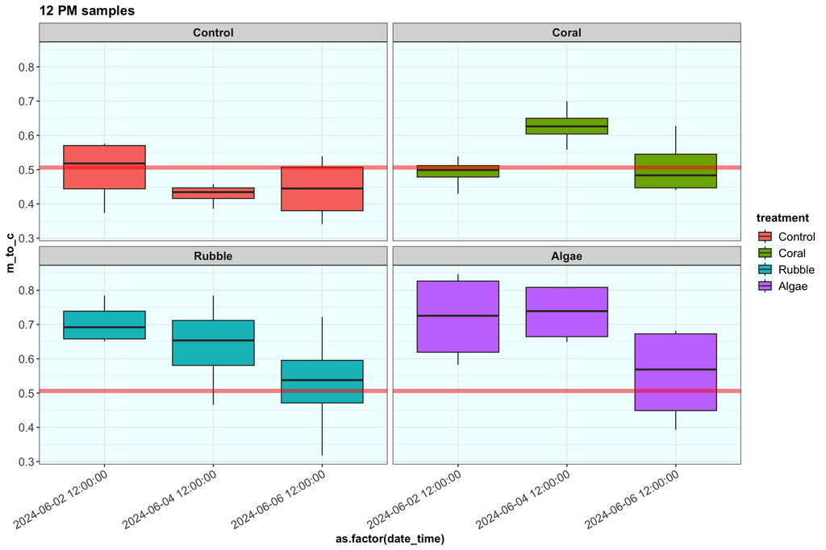

```r
midday_mtoc %>% #mutate(time= as.character(time)) %>%
  #filter(time == "12:00:00") %>%
  ggplot(aes(x= as.factor(date_time), y = m_to_c,
             group= date_time, fill = treatment)) +
  geom_boxplot()+
  geom_hline(yintercept = 0.5063610 , color = "red", linewidth = 2, alpha = 0.5)+
  facet_wrap(.~ treatment )+
  labs(title = "12 PM samples")+
  nunu_theme +
  theme(axis.text.x = element_text(angle= 30, hjust= 1))
```

```r
## Creating a df with only the 12PM samples
H24_mtoc <- fDOM_inflow %>%
  filter(date == "2024-06-02" | date == "2024-06-03") %>%
  filter(treatment != "Inflow") %>% # remove the inflow
  mutate(treatment = factor(treatment, # reorder the factor treatments
                            levels = c("Control","Coral",
                                       "Rubble", "Algae"))) %>%
  mutate(date_time = factor(date_time))

## set a linear model
H24_mtoc_lm <- lm(m_to_c ~ date_time*treatment, data = H24_mtoc)

## anova to see differences between date_time
Anova(H24_mtoc_lm)
```

```
## Anova Table (Type II tests)
##
## Response: m_to_c
##                      Sum Sq Df F value    Pr(>F)
## date_time           0.33114  3 15.0942 4.741e-07 ***
## treatment           0.31731  3 14.4637 7.672e-07 ***
## date_time:treatment 0.05862  9  0.8906    0.5406
## Residuals           0.35101 48
## ---
## Signif. codes:  0 '***' 0.001 '**' 0.01 '*' 0.05 '.' 0.1 ' ' 1
```

```r
## contrast between control and treatments
pairs(emmeans(H24_mtoc_lm, specs = trt.vs.ctrl ~ date_time))
```

```
##  contrast                                      estimate     SE df t.ratio
##  (2024-06-02 12:00:00) - (2024-06-02 18:00:00)  -0.1114 0.0302 48  -3.684
##  (2024-06-02 12:00:00) - (2024-06-03)           -0.0565 0.0302 48  -1.868
##  (2024-06-02 12:00:00) - (2024-06-03 06:00:00)  -0.1950 0.0302 48  -6.448
##  (2024-06-02 18:00:00) - (2024-06-03)            0.0549 0.0302 48   1.816
##  (2024-06-02 18:00:00) - (2024-06-03 06:00:00)  -0.0836 0.0302 48  -2.765
##  (2024-06-03) - (2024-06-03 06:00:00)           -0.1385 0.0302 48  -4.581
##  p.value
##   0.0032
##   0.2555
##   <.0001
##   0.2786
##   0.0389
##   0.0002
##
## Results are averaged over the levels of: treatment
## P value adjustment: tukey method for comparing a family of 4 estimates
```

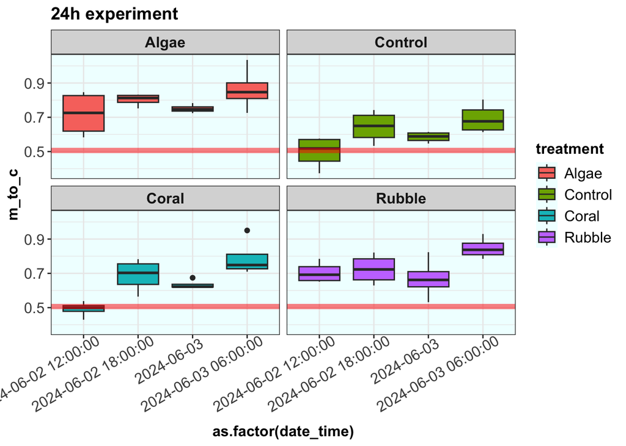

```r
fDOM_inflow %>%
  filter(date == "2024-06-02" | date == "2024-06-03") %>%
  filter(treatment != "Inflow") %>%
  ggplot(aes(x= as.factor(date_time), y = m_to_c,
             group= date_time, fill = treatment)) +
  geom_boxplot()+
  geom_hline(yintercept = 0.5063610 , color = "red", linewidth = 2, alpha = 0.5)+
  facet_wrap(.~ treatment )+
  labs(title = "24h experiment")+
  nunu_theme +
  theme(axis.text.x = element_text(angle= 30, hjust= 0.9))
```

```r
inflow_summary
```

```
## # A tibble: 5 × 3
##   treatment   avg std_dev
##   <chr>     <dbl>   <dbl>
## 1 Algae     0.737  0.134
## 2 Control   0.548  0.123
## 3 Coral     0.623  0.124
## 4 Inflow    0.506  0.0731
## 5 Rubble    0.686  0.139
```

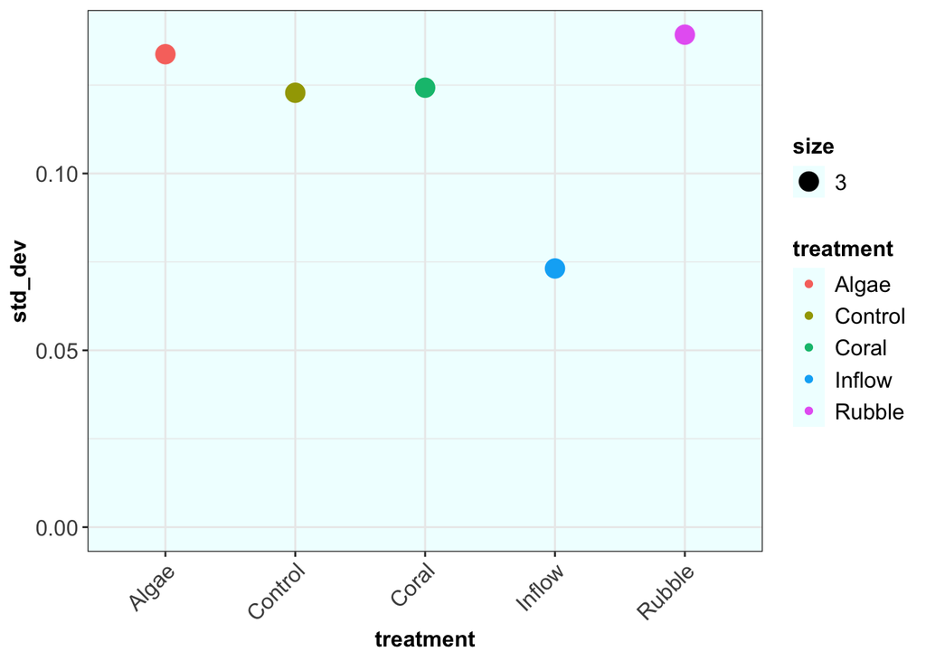

```r
point_graph
```

```r
# run contrast between control and treatment
  ##  set up linear model to analyze contrasts
fDOM_lm <- lm(m_to_c ~ treatment, data = fDOM_ctrl_trmt)


  ## run emmeans to see the difference btwn control and treatment
emmeans(fDOM_lm, specs=(trt.vs.ctrl ~ treatment))
```

```
## $emmeans
##  treatment emmean     SE df lower.CL upper.CL
##  Control    0.548 0.0266 92    0.495    0.601
##  Coral      0.623 0.0266 92    0.570    0.676
##  Rubble     0.686 0.0266 92    0.633    0.738
##  Algae      0.737 0.0266 92    0.684    0.790
##
## Confidence level used: 0.95
##
## $contrasts
##  contrast         estimate     SE df t.ratio p.value
##  Coral - Control    0.0752 0.0376 92   2.002  0.1242
##  Rubble - Control   0.1377 0.0376 92   3.665  0.0012
##  Algae - Control    0.1892 0.0376 92   5.034  <.0001
##
## P value adjustment: dunnettx method for 3 tests
```

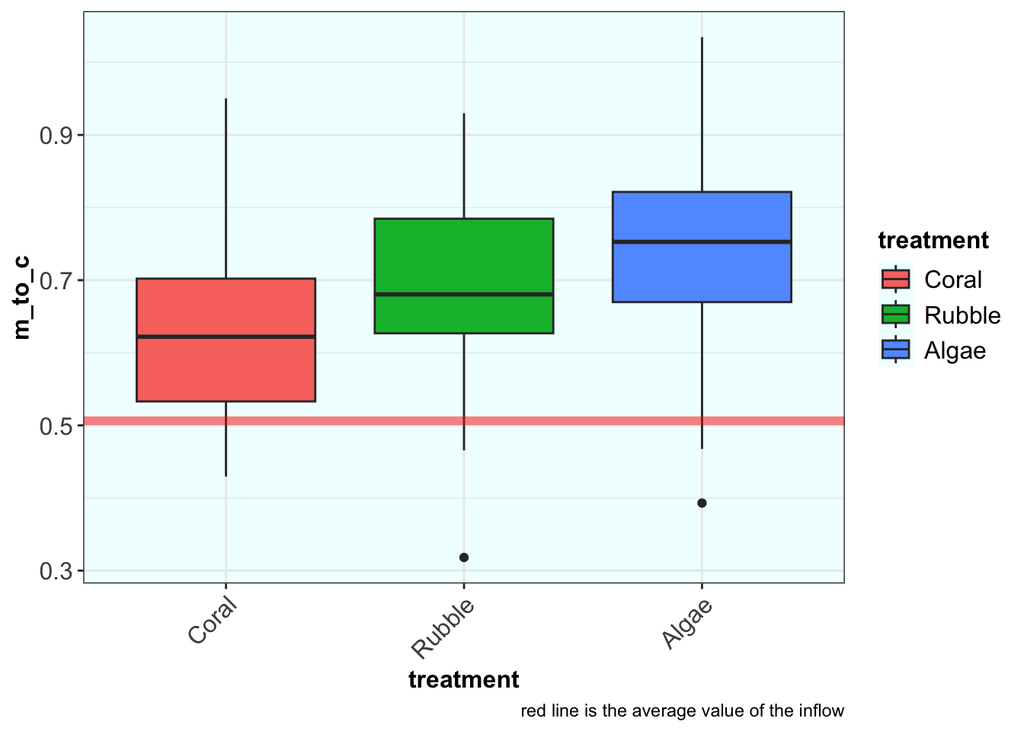

```r
fDOM_ctrl_trmt %>% filter(treatment != "Control") %>%
   ggplot(aes(x= treatment, y= m_to_c))+
  geom_boxplot(aes(fill = treatment)) +
  geom_hline(yintercept = 0.5063610 , color = "red", linewidth = 2, alpha = 0.5)+
  labs(caption = "red line is the average value of the inflow")+
  nunu_theme
```

### Fpeak

```r
fDOM_hyp_test(data = fDOM, fDOM_var = fpeak)
```

```
## [1] "Outputs: endmem_summary, heat_map, boxgraph, fDOM_inflow, inflow_summary,\n        point_graph, fDOM_ctrl_trmt"
```

```r
endmem_summary
```

```
## # A tibble: 9 × 3
##   sample_type    avg    std_dev
##   <chr>        <dbl>      <dbl>
## 1 Algae       0.0279  0.0138
## 2 Bay         0.0889  0.0113
## 3 Control     0.0301  0.0226
## 4 Coral       0.0288  0.0211
## 5 Inflow      0.0272  0.0153
## 6 Lagoon      0.0750  0.0284
## 7 Ocean       0.0896  0.0000965
## 8 Rain        0.0715 NA
## 9 Rubble      0.0183  0.0182
```

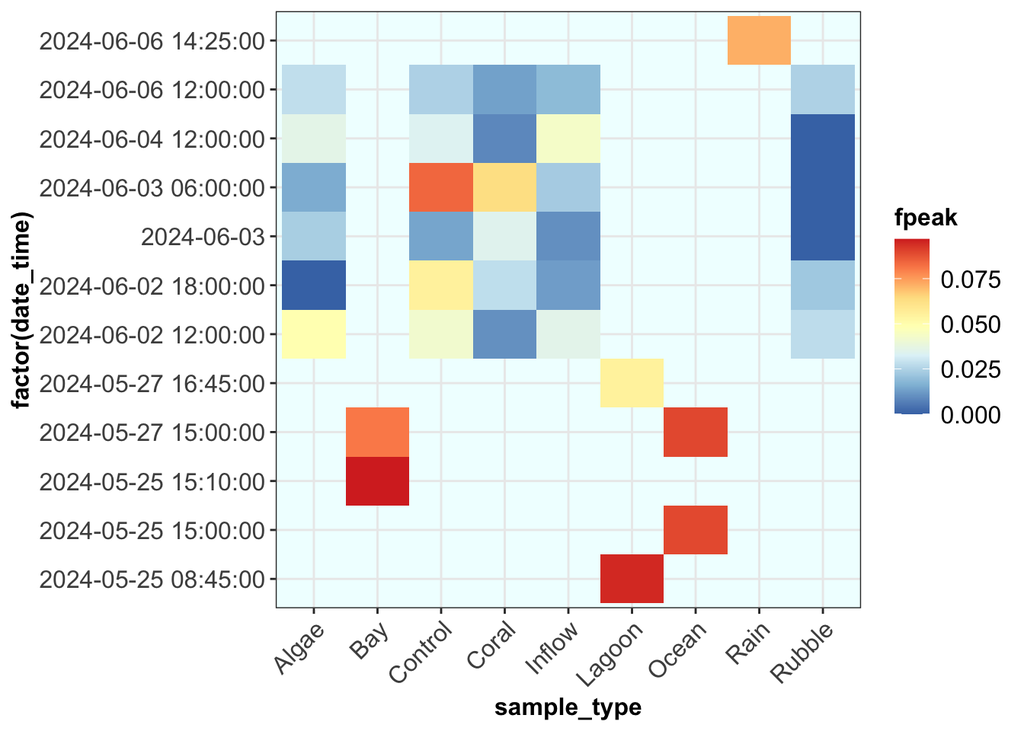

```r
heat_map
```

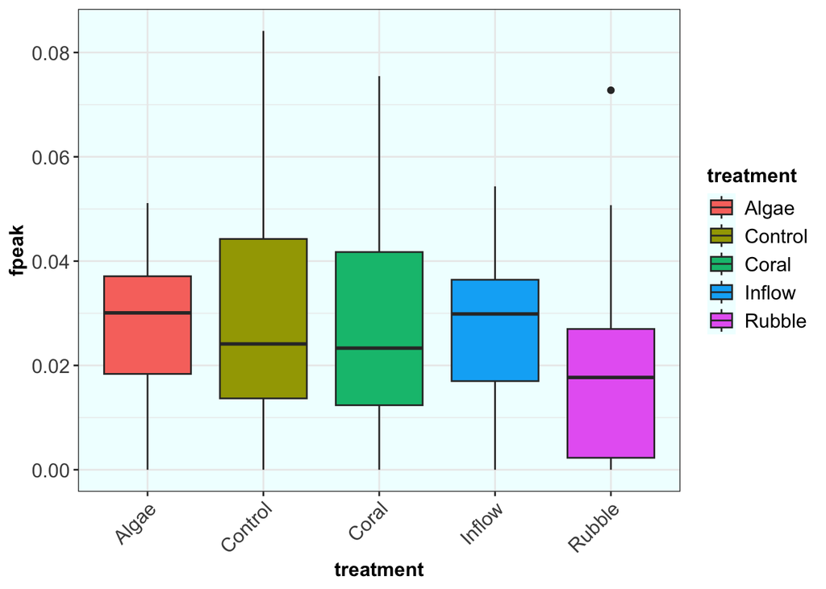

```r
boxgraph
```

```r
inflow_summary
```

```
## # A tibble: 5 × 3
##   treatment    avg std_dev
##   <chr>      <dbl>   <dbl>
## 1 Algae     0.0279  0.0138
## 2 Control   0.0301  0.0226
## 3 Coral     0.0288  0.0211
## 4 Inflow    0.0272  0.0153
## 5 Rubble    0.0183  0.0182
```

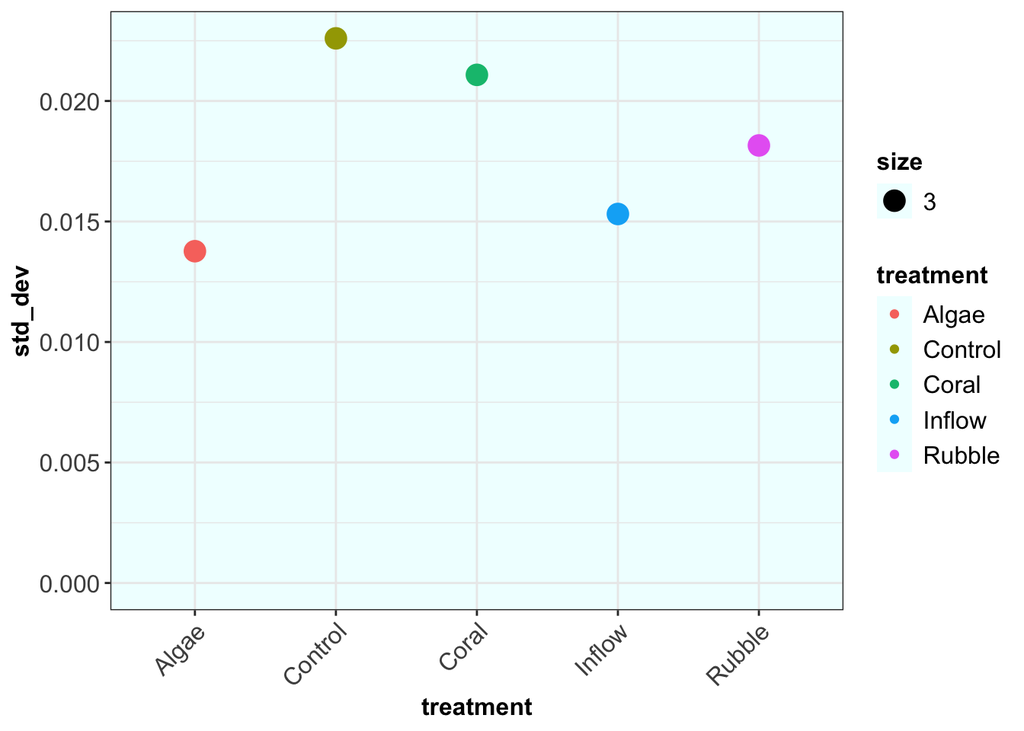

```r
point_graph
```

```r
# run contrast between control and treatment
  ##  set up linear model to analyze contrasts
fDOM_lm <- lm(fpeak ~ treatment, data = fDOM_ctrl_trmt)


  ## run emmeans to see the difference btwn control and treatment
emmeans(fDOM_lm, specs=(trt.vs.ctrl ~ treatment))
```

```
## $emmeans
##  treatment emmean      SE df lower.CL upper.CL
##  Control   0.0301 0.00392 92   0.0223   0.0379
##  Coral     0.0288 0.00392 92   0.0210   0.0366
##  Rubble    0.0183 0.00392 92   0.0105   0.0261
##  Algae     0.0279 0.00392 92   0.0201   0.0357
##
## Confidence level used: 0.95
##
## $contrasts
##  contrast         estimate      SE df t.ratio p.value
##  Coral - Control  -0.00129 0.00554 92  -0.233  0.9783
##  Rubble - Control -0.01182 0.00554 92  -2.133  0.0936
##  Algae - Control  -0.00216 0.00554 92  -0.389  0.9374
##
## P value adjustment: dunnettx method for 3 tests
```

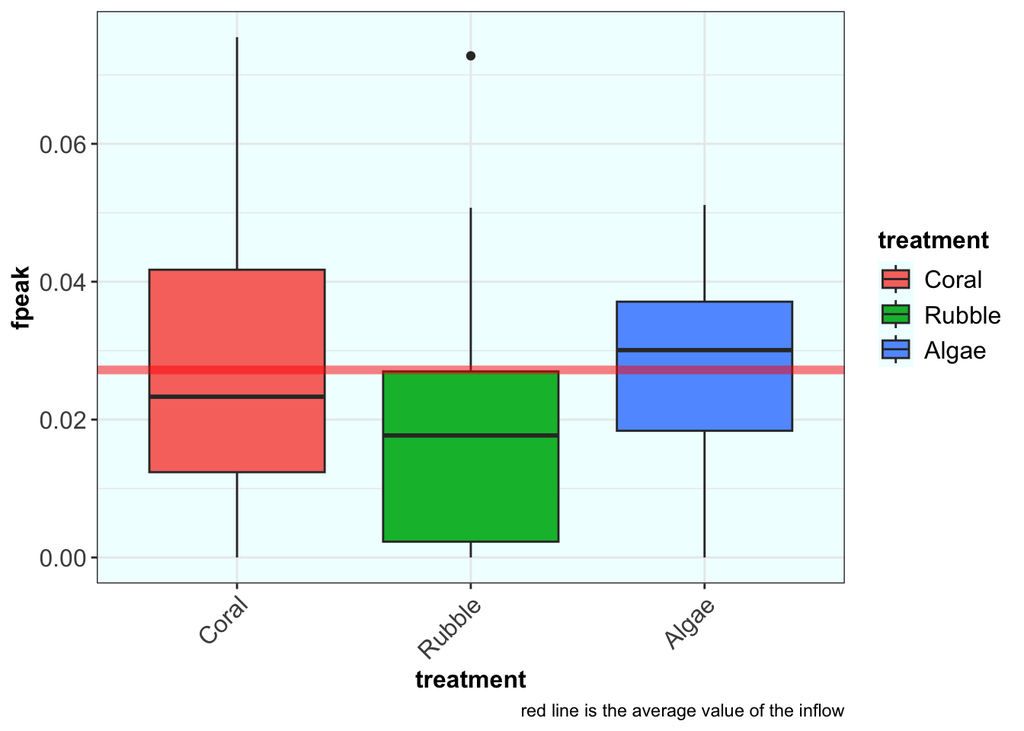

```r
fDOM_ctrl_trmt %>% filter(treatment != "Control") %>%
   ggplot(aes(x= treatment, y= fpeak))+
  geom_boxplot(aes(fill = treatment)) +
  geom_hline(yintercept = 0.02720418        , color = "red", linewidth = 2, alpha = 0.5)+
  labs(caption = "red line is the average value of the inflow")+
  nunu_theme
```